# Predicting FANG Stock Prices: Modeling cointegrated time series data using VECMs

Financial data is the best known resource for time series data. Records of stock prices have been meticulously recorded for over a century providing rich data sets. The stocks of the so-called ‘FANG’ companies, Facebook, Amazon, Netflix, and Google/Alphabet, have gotten a lot of attention for their impressive returns and the ‘cool’ factor of these high-tech companies. But are these stocks truly related to each other? Or is this an example of Wall Street marketing a bundle of unrelated goods (see BRICS)? It’s also possible that the perception that they are related by investors is enough to cause their stocks to move together. Even if we can’t tell why they move together if they do, we can at least determine if they move together.

To find out, I got data from Yahoo Finance for the closing prices of the FANG stocks. Facebook’s IPO was in 2012, so it was the limiting factor in terms of sample period. Our sample period goes from May 18, 2012 to August 23, 2019. I cut off all the trading days in 2019 as a testing data set and left the remaining observations for the training data set. This means the data set lacks data for how these companies’ stocks acted in a recession. Regardless, I proceeded with my analysis. I tested for degree of integration, Granger causality, and Johansen integration. Based on the results, I proceeded with vector error correction modeling (VECM), which is a technique for simultaneously estimating multiple time series with at least 1 cointegrated relationship.

```r
# for time series plotting
suppressMessages(library(ggplot2))
suppressMessages(library(xts))
suppressMessages(library(dygraphs))
# for dataframe manipulation
suppressMessages(library(dplyr))
# for VEC modeling
suppressMessages(library(tsDyn))
# for the ACF plot
suppressMessages(library(forecast))
# for the ADF-test
suppressMessages(library(aTSA))
# for the Granger causality test
suppressMessages(library(lmtest))
# for the Johansen Cointegration test
suppressMessages(library(urca))

# loads in the data
fb = read.csv('FB.csv')
amzn = read.csv('AMZN.csv')
nflx = read.csv('NFLX.csv')
googl = read.csv('GOOGL.csv')

# converts the Date columns to Date objects
fb = fb %>%
   mutate(Date = as.Date(Date, format = '%Y-%m-%d'))
amzn = amzn %>%
   mutate(Date = as.Date(Date, format = '%Y-%m-%d'))
nflx = nflx %>%
   mutate(Date = as.Date(Date, format = '%Y-%m-%d'))
googl = googl %>%
   mutate(Date = as.Date(Date, format = '%Y-%m-%d'))

# creates a dataframe combining fb and aapl by the Date column
fa = inner_join(fb, amzn, by = 'Date', suffix = c('.fb', '.amzn'))
# creates a dataframe combining nflx and googl by the Date column
ng = inner_join(nflx, googl, by = 'Date', suffix = c('.nflx', '.googl'))
# combines them into 1 dataframe
fang = inner_join(fa, ng, by = 'Date')

# creates training and testing data sets with only closing prices
train = fang %>%
  filter(Date < '2019-01-01') %>%
  dplyr::select(Date, starts_with('Close.'))
test = fang %>%
  filter(Date >= '2019-01-01')%>%
  dplyr::select(Date, starts_with('Close.'))

# attaches the indicies dataframe so I don't need to keep typing fang$ before a column name
attach(fang)

# plots the indices with the htmlwidget dygraphs
# dygraph() needs xts time series objects
fb_xts <- xts(Close.fb, order.by = fang$Date, frequency = 365)
amzn_xts <- xts(Close.amzn, order.by = fang$Date, frequency = 365)
nflx_xts <- xts(Close.nflx, order.by = fang$Date, frequency = 365)
googl_xts <- xts(Close.googl, order.by = fang$Date, frequency = 365)
# creates a combined xts object
fang_xts <- cbind(fb_xts, amzn_xts, nflx_xts, googl_xts)
# plots the indices
dygraph(fang_xts, ylab = 'Closing Share Price',
        main = 'Closing Share Prices of FANG stocks') %>%
  dySeries('fb_xts', label = 'FB') %>%
  dySeries('amzn_xts', label = 'AMZN') %>%
  dySeries('nflx_xts', label = 'NFLX') %>%
  dySeries('googl_xts', label = 'GOOGL') %>%
  dyOptions(colors = c('blue', 'orange', 'red', 'green')) %>%
  dyRangeSelector()
```

[interactive chart not shown]

# **Testing for Stationarity**

Stationarity is where the mean an variance of a time series is not dependent on time. When graphed, it looks like white noise. Due to several problems caused by modeling non-stationary time series, chiefly autocorrelation, you need to check if a time-series is stationary prior to modeling. If it is not stationary, you need to get it there through differencing.

A glance at the graph above shows 4 time series that definitely look non-stationary. However, we need to formally test for it before proceeding.

The plots of the Auto-Correlation Functions (ACFs) of the non-differenced variables show that stocks are definitely not stationary. The ACFs of the differenced variables look potentially stationary. This suggests each stock is integrated I(1). Augmented Dickey-Fuller (ADF) tests can confirm this.

### **Auto-Correlation Function Plots for Facebook**

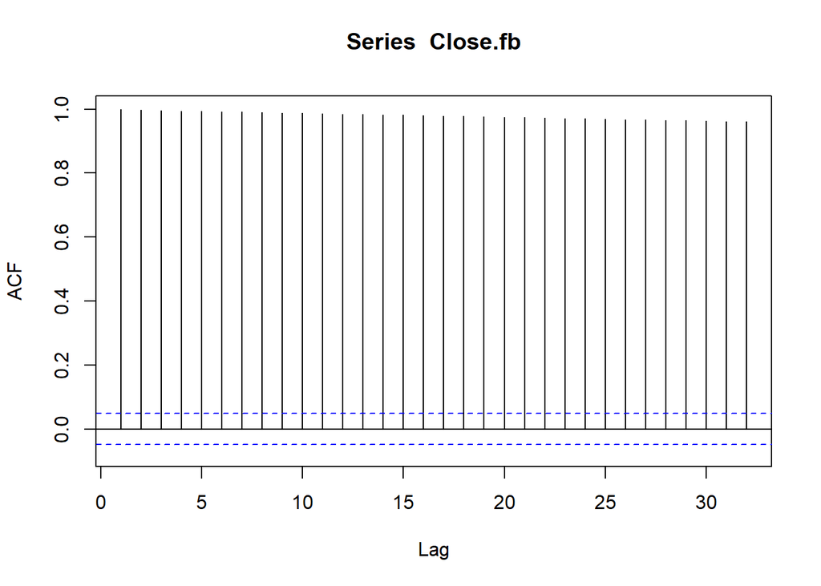

```r
# attaches the indicies dataframe so I don't need to keep typing train$ before a column name
attach(train)

Acf(Close.fb, lag.max = NULL, type = c("correlation", "covariance",
  "partial"), plot = TRUE, na.action = na.contiguous, demean = TRUE)
```

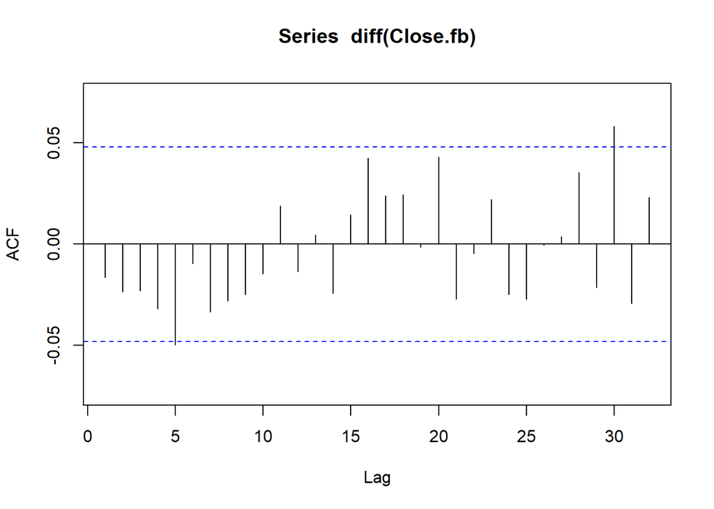

```r
Acf(diff(Close.fb), lag.max = NULL, type = c("correlation", "covariance",
  "partial"), plot = TRUE, na.action = na.contiguous, demean = TRUE)
```

### **Auto-Correlation Function Plots for Amazon**

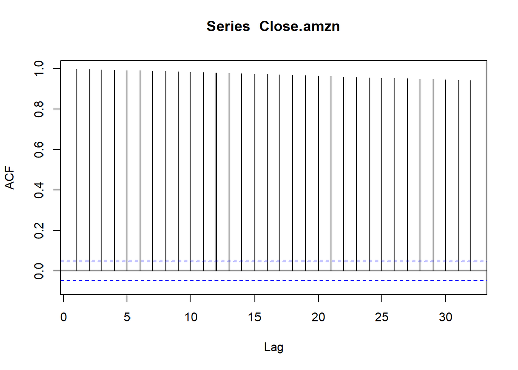

```r
Acf(Close.amzn, lag.max = NULL, type = c("correlation", "covariance",
  "partial"), plot = TRUE, na.action = na.contiguous, demean = TRUE)
```

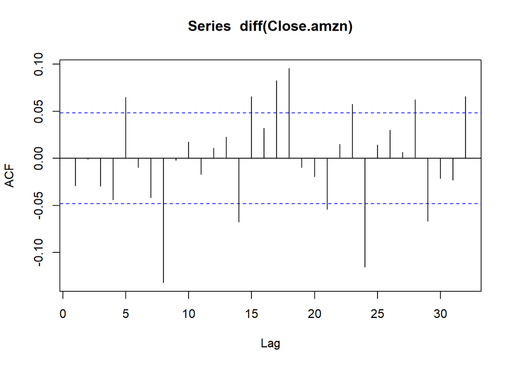

```r
Acf(diff(Close.amzn), lag.max = NULL, type = c("correlation", "covariance",
  "partial"), plot = TRUE, na.action = na.contiguous, demean = TRUE)
```

### **Auto-Correlation Function Plots for Netflix**

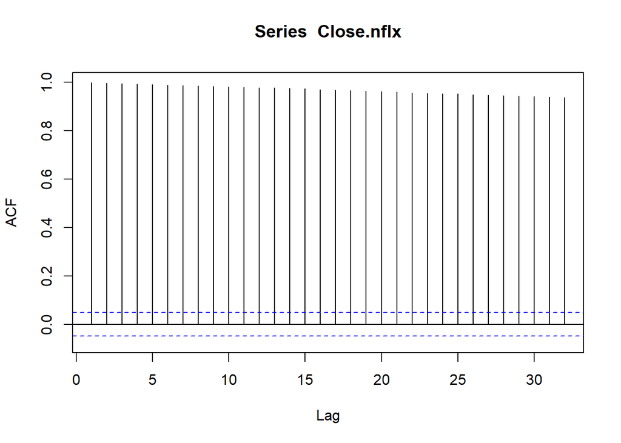

```r
Acf(Close.nflx, lag.max = NULL, type = c("correlation", "covariance",
  "partial"), plot = TRUE, na.action = na.contiguous, demean = TRUE)
```

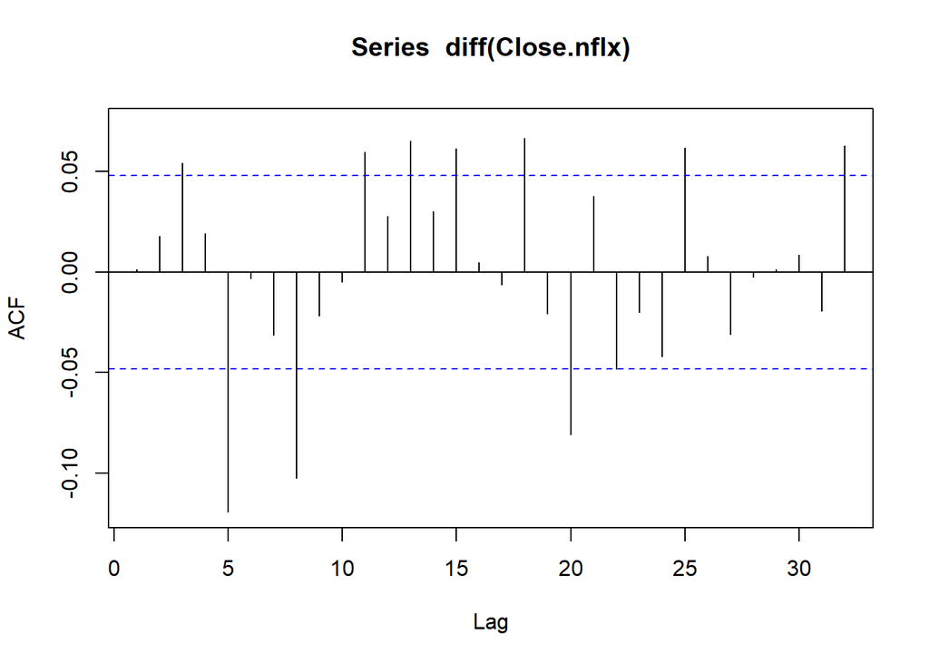

```r
Acf(diff(Close.nflx), lag.max = NULL, type = c("correlation", "covariance",
  "partial"), plot = TRUE, na.action = na.contiguous, demean = TRUE)
```

### **Auto-Correlation Function Plots for Google**

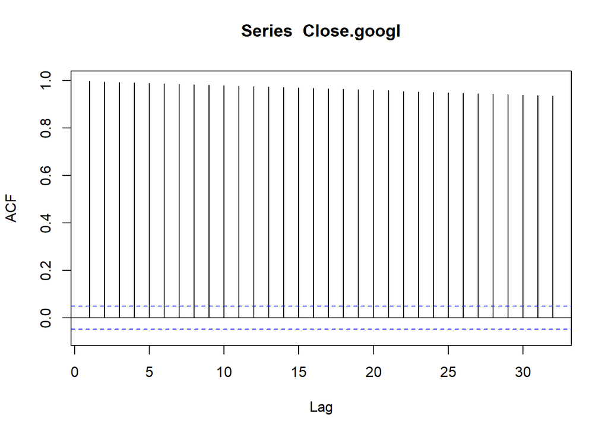

```r
Acf(Close.googl, lag.max = NULL, type = c("correlation", "covariance",
  "partial"), plot = TRUE, na.action = na.contiguous, demean = TRUE)
```

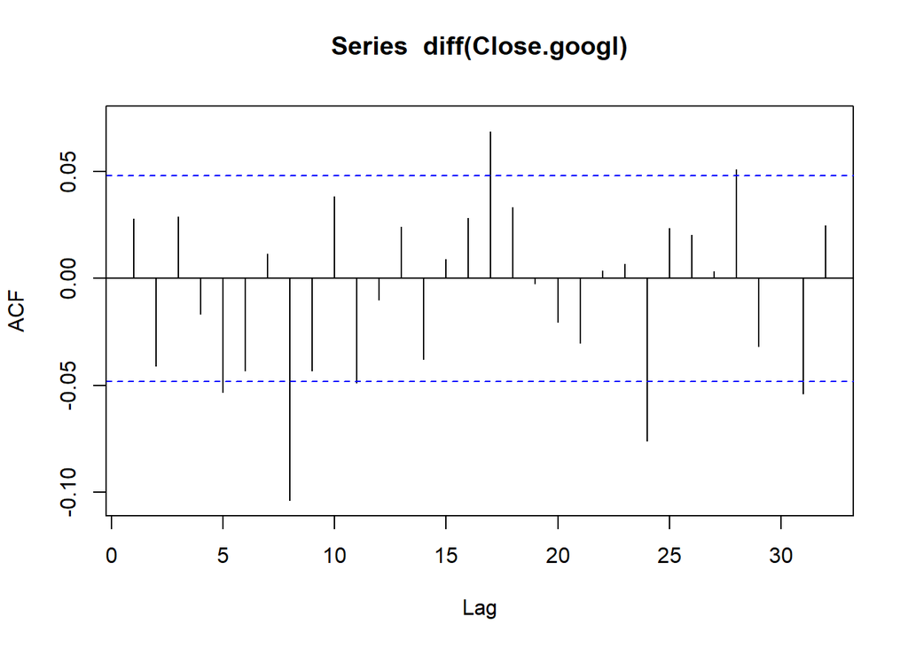

```r
Acf(diff(Close.googl), lag.max = NULL, type = c("correlation", "covariance",
  "partial"), plot = TRUE, na.action = na.contiguous, demean = TRUE)
```

The output of the ADF tests for the non-differenced and differenced strongly support the hypothesis that the stocks are integrated I(1). These stock prices need to be differenced once prior to modeling. Many time series packages for integrated time series models do this automatically.

### **Augmented Dickey-Fuller Tests for Facebook**

```r
adf.test(Close.fb, output = TRUE)
```

```
## Augmented Dickey-Fuller Test
## alternative: stationary
##
## Type 1: no drift no trend
##      lag   ADF p.value
## [1,]   0 0.405   0.760
## [2,]   1 0.441   0.771
## [3,]   2 0.483   0.783
## [4,]   3 0.508   0.790
## [5,]   4 0.542   0.800
## [6,]   5 0.608   0.819
## [7,]   6 0.639   0.828
## [8,]   7 0.692   0.843
## Type 2: with drift no trend
##      lag   ADF p.value
## [1,]   0 -1.11   0.661
## [2,]   1 -1.16   0.644
## [3,]   2 -1.19   0.634
## [4,]   3 -1.17   0.642
## [5,]   4 -1.14   0.651
## [6,]   5 -1.14   0.651
## [7,]   6 -1.19   0.635
## [8,]   7 -1.19   0.635
## Type 3: with drift and trend
##      lag   ADF p.value
## [1,]   0 -2.42   0.399
## [2,]   1 -2.25   0.469
## [3,]   2 -2.08   0.541
## [4,]   3 -2.01   0.572
## [5,]   4 -1.88   0.628
## [6,]   5 -1.60   0.745
## [7,]   6 -1.47   0.803
## [8,]   7 -1.28   0.881
## ----
## Note: in fact, p.value = 0.01 means p.value <= 0.01
```

```r
adf.test(diff(Close.fb), output = TRUE)
```

```
## Augmented Dickey-Fuller Test
## alternative: stationary
##
## Type 1: no drift no trend
##      lag   ADF p.value
## [1,]   0 -41.5    0.01
## [2,]   1 -29.8    0.01
## [3,]   2 -24.6    0.01
## [4,]   3 -21.7    0.01
## [5,]   4 -20.1    0.01
## [6,]   5 -18.3    0.01
## [7,]   6 -17.3    0.01
## [8,]   7 -16.4    0.01
## Type 2: with drift no trend
##      lag   ADF p.value
## [1,]   0 -41.5    0.01
## [2,]   1 -29.8    0.01
## [3,]   2 -24.6    0.01
## [4,]   3 -21.7    0.01
## [5,]   4 -20.2    0.01
## [6,]   5 -18.4    0.01
## [7,]   6 -17.4    0.01
## [8,]   7 -16.5    0.01
## Type 3: with drift and trend
##      lag   ADF p.value
## [1,]   0 -41.5    0.01
## [2,]   1 -29.8    0.01
## [3,]   2 -24.6    0.01
## [4,]   3 -21.7    0.01
## [5,]   4 -20.2    0.01
## [6,]   5 -18.4    0.01
## [7,]   6 -17.4    0.01
## [8,]   7 -16.5    0.01
## ----
## Note: in fact, p.value = 0.01 means p.value <= 0.01
```

### **Augmented Dickey-Fuller Tests for Amazon**

```r
adf.test(Close.amzn, output = TRUE)
```

```
## Augmented Dickey-Fuller Test
## alternative: stationary
##
## Type 1: no drift no trend
##      lag  ADF p.value
## [1,]   0 1.54   0.969
## [2,]   1 1.60   0.974
## [3,]   2 1.60   0.974
## [4,]   3 1.67   0.977
## [5,]   4 1.76   0.980
## [6,]   5 1.62   0.975
## [7,]   6 1.63   0.976
## [8,]   7 1.75   0.980
## Type 2: with drift no trend
##      lag      ADF p.value
## [1,]   0 -0.03873   0.953
## [2,]   1  0.00509   0.956
## [3,]   2  0.00206   0.956
## [4,]   3  0.04246   0.959
## [5,]   4  0.08628   0.963
## [6,]   5  0.01241   0.957
## [7,]   6  0.02187   0.957
## [8,]   7  0.07776   0.962
## Type 3: with drift and trend
##      lag   ADF p.value
## [1,]   0 -1.93   0.605
## [2,]   1 -1.90   0.619
## [3,]   2 -1.89   0.622
## [4,]   3 -1.86   0.637
## [5,]   4 -1.80   0.663
## [6,]   5 -1.87   0.631
## [7,]   6 -1.87   0.634
## [8,]   7 -1.80   0.664
## ----
## Note: in fact, p.value = 0.01 means p.value <= 0.01
```

```r
adf.test(diff(Close.amzn), output = TRUE)
```

```
## Augmented Dickey-Fuller Test
## alternative: stationary
##
## Type 1: no drift no trend
##      lag   ADF p.value
## [1,]   0 -41.9    0.01
## [2,]   1 -29.1    0.01
## [3,]   2 -24.3    0.01
## [4,]   3 -21.7    0.01
## [5,]   4 -17.8    0.01
## [6,]   5 -16.4    0.01
## [7,]   6 -15.9    0.01
## [8,]   7 -16.9    0.01
## Type 2: with drift no trend
##      lag   ADF p.value
## [1,]   0 -41.9    0.01
## [2,]   1 -29.2    0.01
## [3,]   2 -24.4    0.01
## [4,]   3 -21.8    0.01
## [5,]   4 -17.9    0.01
## [6,]   5 -16.5    0.01
## [7,]   6 -16.0    0.01
## [8,]   7 -17.1    0.01
## Type 3: with drift and trend
##      lag   ADF p.value
## [1,]   0 -41.9    0.01
## [2,]   1 -29.2    0.01
## [3,]   2 -24.5    0.01
## [4,]   3 -21.8    0.01
## [5,]   4 -18.0    0.01
## [6,]   5 -16.5    0.01
## [7,]   6 -16.1    0.01
## [8,]   7 -17.1    0.01
## ----
## Note: in fact, p.value = 0.01 means p.value <= 0.01
```

### **Augmented Dickey-Fuller Tests for Netflix**

```r
adf.test(Close.nflx, output = TRUE)
```

```
## Augmented Dickey-Fuller Test
## alternative: stationary
##
## Type 1: no drift no trend
##      lag   ADF p.value
## [1,]   0 0.837   0.885
## [2,]   1 0.833   0.884
## [3,]   2 0.799   0.874
## [4,]   3 0.701   0.846
## [5,]   4 0.670   0.837
## [6,]   5 0.880   0.897
## [7,]   6 0.890   0.900
## [8,]   7 0.946   0.907
## Type 2: with drift no trend
##      lag    ADF p.value
## [1,]   0 -0.516   0.873
## [2,]   1 -0.517   0.873
## [3,]   2 -0.541   0.864
## [4,]   3 -0.598   0.844
## [5,]   4 -0.618   0.837
## [6,]   5 -0.492   0.882
## [7,]   6 -0.486   0.884
## [8,]   7 -0.455   0.895
## Type 3: with drift and trend
##      lag   ADF p.value
## [1,]   0 -2.00   0.576
## [2,]   1 -2.01   0.574
## [3,]   2 -2.04   0.562
## [4,]   3 -2.14   0.517
## [5,]   4 -2.18   0.501
## [6,]   5 -1.95   0.597
## [7,]   6 -1.94   0.602
## [8,]   7 -1.89   0.623
## ----
## Note: in fact, p.value = 0.01 means p.value <= 0.01
```

```r
adf.test(diff(Close.nflx), output = TRUE)
```

```
## Augmented Dickey-Fuller Test
## alternative: stationary
##
## Type 1: no drift no trend
##      lag   ADF p.value
## [1,]   0 -40.6    0.01
## [2,]   1 -28.2    0.01
## [3,]   2 -21.9    0.01
## [4,]   3 -18.8    0.01
## [5,]   4 -19.2    0.01
## [6,]   5 -17.5    0.01
## [7,]   6 -16.5    0.01
## [8,]   7 -16.7    0.01
## Type 2: with drift no trend
##      lag   ADF p.value
## [1,]   0 -40.6    0.01
## [2,]   1 -28.2    0.01
## [3,]   2 -21.9    0.01
## [4,]   3 -18.8    0.01
## [5,]   4 -19.3    0.01
## [6,]   5 -17.6    0.01
## [7,]   6 -16.6    0.01
## [8,]   7 -16.9    0.01
## Type 3: with drift and trend
##      lag   ADF p.value
## [1,]   0 -40.6    0.01
## [2,]   1 -28.2    0.01
## [3,]   2 -21.9    0.01
## [4,]   3 -18.8    0.01
## [5,]   4 -19.3    0.01
## [6,]   5 -17.6    0.01
## [7,]   6 -16.6    0.01
## [8,]   7 -16.9    0.01
## ----
## Note: in fact, p.value = 0.01 means p.value <= 0.01
```

### **Augmented Dickey-Fuller Tests for Google**

```r
adf.test(Close.googl, output = TRUE)
```

```
## Augmented Dickey-Fuller Test
## alternative: stationary
##
## Type 1: no drift no trend
##      lag  ADF p.value
## [1,]   0 1.21   0.940
## [2,]   1 1.15   0.933
## [3,]   2 1.23   0.943
## [4,]   3 1.16   0.935
## [5,]   4 1.20   0.939
## [6,]   5 1.28   0.950
## [7,]   6 1.36   0.956
## [8,]   7 1.34   0.954
## Type 2: with drift no trend
##      lag   ADF p.value
## [1,]   0 -1.07   0.677
## [2,]   1 -1.07   0.679
## [3,]   2 -1.06   0.680
## [4,]   3 -1.07   0.678
## [5,]   4 -1.07   0.676
## [6,]   5 -1.07   0.677
## [7,]   6 -1.04   0.687
## [8,]   7 -1.06   0.680
## Type 3: with drift and trend
##      lag   ADF p.value
## [1,]   0 -3.52  0.0404
## [2,]   1 -3.64  0.0275
## [3,]   2 -3.49  0.0430
## [4,]   3 -3.63  0.0292
## [5,]   4 -3.56  0.0364
## [6,]   5 -3.36  0.0598
## [7,]   6 -3.22  0.0851
## [8,]   7 -3.26  0.0768
## ----
## Note: in fact, p.value = 0.01 means p.value <= 0.01
```

```r
adf.test(diff(Close.googl), output = TRUE)
```

```
## Augmented Dickey-Fuller Test
## alternative: stationary
##
## Type 1: no drift no trend
##      lag   ADF p.value
## [1,]   0 -39.6    0.01
## [2,]   1 -29.5    0.01
## [3,]   2 -23.1    0.01
## [4,]   3 -20.4    0.01
## [5,]   4 -19.1    0.01
## [6,]   5 -18.0    0.01
## [7,]   6 -16.3    0.01
## [8,]   7 -16.8    0.01
## Type 2: with drift no trend
##      lag   ADF p.value
## [1,]   0 -39.6    0.01
## [2,]   1 -29.6    0.01
## [3,]   2 -23.2    0.01
## [4,]   3 -20.5    0.01
## [5,]   4 -19.2    0.01
## [6,]   5 -18.1    0.01
## [7,]   6 -16.4    0.01
## [8,]   7 -16.9    0.01
## Type 3: with drift and trend
##      lag   ADF p.value
## [1,]   0 -39.6    0.01
## [2,]   1 -29.6    0.01
## [3,]   2 -23.2    0.01
## [4,]   3 -20.5    0.01
## [5,]   4 -19.2    0.01
## [6,]   5 -18.1    0.01
## [7,]   6 -16.4    0.01
## [8,]   7 -16.9    0.01
## ----
## Note: in fact, p.value = 0.01 means p.value <= 0.01
```

# **Granger Causality**

Establishing causality in observational data is notoriously difficult. Granger causality is a lower bar. It simply says that if previous values of X can predict future values of y, then X Granger causes y. It is performed by estimating the regression of the lagged values of X on y and performing an F-test. If the p-value is small enough, you reject the null hypothesis that all the coefficients of the lagged values of X are 0. In plain English, small p-values say that the lagged Xs have predictive power on future y, with a corresponding level of confidence.

The output below simply states that each of the FANG stocks has predictive power over the others. This means simultaneous modeling is a good approach.

```r
# creates a list of the FANG closing share prices to be looped through
fang_list = list(Close.fb, Close.amzn, Close.nflx, Close.googl)
# creates a counter that will be used for removing the ith object from fang_list using it as an index
counter = 1
# loops through fang_list
for(i in fang_list){
  # creates a temporary list
  temp = fang_list
  # removes the closing share prices of the ith stock
  temp[[counter]] <- NULL
  # loops through temp, which is fang_list minus i
  for(j in temp){
    # performs a Granger Causality Test of i's ability to predict j
    print(grangertest(i, j, order = 30))
  }
  # increments the counter
  counter = counter + 1
}
```

```
## Granger causality test
##
## Model 1: j ~ Lags(j, 1:30) + Lags(i, 1:30)
## Model 2: j ~ Lags(j, 1:30)
##   Res.Df  Df      F    Pr(>F)
## 1   1574
## 2   1604 -30 2.9968 1.226e-07 ***
## ---
## Signif. codes:  0 '***' 0.001 '**' 0.01 '*' 0.05 '.' 0.1 ' ' 1
## Granger causality test
##
## Model 1: j ~ Lags(j, 1:30) + Lags(i, 1:30)
## Model 2: j ~ Lags(j, 1:30)
##   Res.Df  Df      F    Pr(>F)
## 1   1574
## 2   1604 -30 2.4849 1.635e-05 ***
## ---
## Signif. codes:  0 '***' 0.001 '**' 0.01 '*' 0.05 '.' 0.1 ' ' 1
## Granger causality test
##
## Model 1: j ~ Lags(j, 1:30) + Lags(i, 1:30)
## Model 2: j ~ Lags(j, 1:30)
##   Res.Df  Df      F   Pr(>F)
## 1   1574
## 2   1604 -30 2.5479 9.15e-06 ***
## ---
## Signif. codes:  0 '***' 0.001 '**' 0.01 '*' 0.05 '.' 0.1 ' ' 1
## Granger causality test
##
## Model 1: j ~ Lags(j, 1:30) + Lags(i, 1:30)
## Model 2: j ~ Lags(j, 1:30)
##   Res.Df  Df      F   Pr(>F)
## 1   1574
## 2   1604 -30 2.5026 1.39e-05 ***
## ---
## Signif. codes:  0 '***' 0.001 '**' 0.01 '*' 0.05 '.' 0.1 ' ' 1
## Granger causality test
##
## Model 1: j ~ Lags(j, 1:30) + Lags(i, 1:30)
## Model 2: j ~ Lags(j, 1:30)
```

[output cut: 53 more lines]

```
## Model 2: j ~ Lags(j, 1:30)
##   Res.Df  Df     F   Pr(>F)
## 1   1574
## 2   1604 -30 1.728 0.008712 **
## ---
## Signif. codes:  0 '***' 0.001 '**' 0.01 '*' 0.05 '.' 0.1 ' ' 1
## Granger causality test
##
## Model 1: j ~ Lags(j, 1:30) + Lags(i, 1:30)
## Model 2: j ~ Lags(j, 1:30)
##   Res.Df  Df      F    Pr(>F)
## 1   1574
## 2   1604 -30 3.3607 3.101e-09 ***
## ---
## Signif. codes:  0 '***' 0.001 '**' 0.01 '*' 0.05 '.' 0.1 ' ' 1
```

# **Testing for Cointegration**

Cointegration is a word I’ve thrown around several times. It simply means that there is a long-run relationship between at least 2 of our stocks. The test for cointegration is known as the Johansen test, named for the statistician/econometrician that developed it. It can be formluted in 2 ways, the Trace test and the Maximum Eigenvalue test, which have different hypotheses. The details are fairly technical, so the long and short of it is if the rank, r, of the long-run relationship matrix is 0 or equal to the number of time series being tested, there is no cointegration and a different modeling technique is appropriate. If r is greater than 0 and less than the number of time series, then there are r cointegrative relationships.

From the output below, we can be very sure that there is greater than 0 cointegrative relationships, but we can not be sure at any reasonable level of statistical significance that there is more than 1 cointegrative relationship. Thus, we will assume there is one cointegrated relationship between the FANG stocks.

```r
johansen = ca.jo(data.frame(Close.fb, Close.amzn, Close.nflx, Close.googl), type = 'trace', K = 30, ecdet = 'trend', spec = 'longrun')
summary(johansen)
```

```
##
## ######################
## # Johansen-Procedure #
## ######################
##
## Test type: trace statistic , with linear trend in cointegration
##
## Eigenvalues (lambda):
## [1]  2.054935e-02  1.133947e-02  6.555429e-03  4.658323e-03 -2.362375e-18
##
## Values of teststatistic and critical values of test:
##
##           test 10pct  5pct  1pct
## r <= 3 |  7.63 10.49 12.25 16.26
## r <= 2 | 18.39 22.76 25.32 30.45
## r <= 1 | 37.03 39.06 42.44 48.45
## r = 0  | 70.98 59.14 62.99 70.05
##
## Eigenvectors, normalised to first column:
## (These are the cointegration relations)
##
##                 Close.fb.l30 Close.amzn.l30 Close.nflx.l30 Close.googl.l30
## Close.fb.l30     1.000000000      1.0000000      1.0000000     1.000000000
## Close.amzn.l30  -0.004276658      1.0364900      0.2719707     0.102530094
## Close.nflx.l30   0.159547714     -1.8623141     -1.2702538    -0.746632744
## Close.googl.l30 -0.143075556     -1.9821424      0.4921765    -0.150661845
## trend.l30       -0.054567826      0.2916345     -0.3575875     0.005284555
##                  trend.l30
## Close.fb.l30     1.0000000
## Close.amzn.l30  -0.1327168
## Close.nflx.l30   0.5949550
## Close.googl.l30  0.2315739
## trend.l30       -0.3248181
##
## Weights W:
## (This is the loading matrix)
##
##               Close.fb.l30 Close.amzn.l30 Close.nflx.l30 Close.googl.l30
## Close.fb.d     -0.00219271  -0.0006776299   -0.003233474      0.00356431
## Close.amzn.d    0.18630132  -0.0084137379   -0.008556667      0.01693689
## Close.nflx.d    0.02105269  -0.0006557141    0.001122418      0.01106052
## Close.googl.d   0.10670446   0.0031632593   -0.012012380      0.01474776
##                   trend.l30
## Close.fb.d     1.732653e-17
## Close.amzn.d  -8.853648e-16
## Close.nflx.d  -1.271123e-16
## Close.googl.d -9.437844e-16
```

# **Choosing the Number of Lags for the Model**

To choose the number of lags to include in the final model, I took a small subset of my training data; the period starting from May 09, 2018 and going until the end of the year. That was the date that left 163 observations in the mini-testing data set, which was equal to the number of observations in the test data set. I then estimated the model with 1 to 30 lags on the mini-training data and then estimated the mini-testing data set with that model. I calculated the mean absolute percentage error (MAPE) for each stock and summed them up. I then selected the number of lags that minimized the summed MAPE of each stock. The number of lags minimizing the summed MAPE in this tuning data set is 5.

```r
# this chunk of code partitions the training data set to smaller training and testing data sets for the purposes of tuning the number
# of lags included in the model

# these create mini partitions
tune_train = train %>%
  filter(Date < '2018-05-09')
tune_test = train %>%
  filter(Date >= '2018-05-09')
# creates an empty vector to store the sum of the MAPE of each stock with the VECM estimated with i lags
total_error = c()
# goes from i to 30, representing the max lags in the model
for(i in seq(30)){

  # sets the number of lags
  lags = i

  # estimates the VECM with i lags
  vecmodel = VECM(data.frame(tune_train$Close.fb, tune_train$Close.amzn, tune_train$Close.nflx, tune_train$Close.googl),
                  lag = lags, r = 1, include = 'const', estim = '2OLS')


  # the chunk of code below makes rolling predictions

  # creates an empty dataframe to store predictions
  predictions = data.frame()
  # loops through the rows in the test data minus the last number of rows equal to the number of lags
  for(row in seq(dim(test)[1] - lags)){
    # creates a temporary test data set with the number of rows equal to the number of lags + 1, because the data will be differenced
    temp_test = tune_test[row:(row + lags),] %>%
      # removes Date because the predict function can only intake actual variables of interest
      dplyr::select(-Date)
    # appends the predictions
    predictions = rbind(predictions, data.frame(predict(vecmodel, newdata = temp_test, n.ahead = 1)))
  }

  # grabs the dates from the testing data set that we made predictions for
  Date = tail(test, dim(predictions)[1])$Date
  # attaches the Dates to the predictions
  predictions = cbind(predictions, Date)
  # joins actual and predicted values
  tune_testing = inner_join(predictions, tail(test, dim(predictions)[1]), by = 'Date', suffix = c('.hat', '.actual'))
  # creates a dataframe that
  model_error = data.frame()
  # initializes mape
  mape_list = c()

  # loops through the stocks
  for(j in list('Close.fb', 'Close.amzn', 'Close.nflx', 'Close.googl')){
    # selects the fitted and actual values for each stock
    temp = tune_testing %>%
      dplyr::select(contains(j))

    # calculates the absolue percent difference from the actual share price
    perc_diff = abs((temp[,2] - temp[,1]) / temp[,2])
    # sums the percent differences and divides by the number of rows in the testing data set and multiplies it by 100%
    mape = 100 * sum(perc_diff) / dim(temp)[1]
    # adds the mape to the mape list
    mape_list = c(mape_list, mape)
  }
  # appends the sum of the mapes to the total error vector
  total_error = c(total_error, sum(mape_list))
}
# returns the index of the lowest value, which is the number of lags producing the smallest sum of MAPE's of each stock
which.min(total_error)
```

```
## [1] 5
```

# **How Accurate is the Model?**

When assessing model accuracy, it helps to have a baseline comparison. For classification, it could be the misclassification rate of always predicting the mode. For cross-sectional regression, it can be the average value of the dependent variable. For time series, I like to have my prediction be the value from the previous period of time. That means my baseline accuracy rating is the accuracy of saying the stock price tomorrow will be the stock price today.

Doing this produces a baseline MAPE of 1.36% for Facebook, 1.20% for Amazon, 1.70% for Netflix, and 1.15% for Google. That’s not too bad for a prediction method that doesn’t rely on complicated statistical models. Can the VECM outperform this?

```r
# this chunk of code prints out the MAPE for just predicting the stocks price with the price the period before

suppressMessages(attach(test))

baseline = data.frame(lag(Close.fb))
baseline = cbind(baseline, lag(Close.amzn))
baseline = cbind(baseline, lag(Close.nflx))
baseline = cbind(baseline, lag(Close.googl))
Date = test$Date
baseline = cbind(baseline, Date)

baseline = inner_join(baseline, test, by = 'Date')

baseline = baseline %>%
  na.omit()

for(i in list('Close.fb', 'Close.amzn', 'Close.nflx', 'Close.googl')){
  temp = baseline %>%
    filter(Date >= baseline$Date[1]) %>%
    dplyr::select(contains(i))
  actual = temp[,2]
  fitted = temp[,1]
  perc_diff = abs((actual - fitted) / actual)
  mape = 100 * sum(perc_diff) / dim(temp)[1]
  print(i)
  print(mape)
}
```

```
## [1] "Close.fb"
## [1] 1.360928
## [1] "Close.amzn"
## [1] 1.203783
## [1] "Close.nflx"
## [1] 1.697295
## [1] "Close.googl"
## [1] 1.150686
```

Yes. The VECM produces a MAPE of 0.30% for Facebook, 0.28% for Amazon, 0.40% for Netflix, and 0.29% for Google, which isn’t too shabby. These MAPE’s are roughly a quarter of the baseline error rates.

```r
suppressMessages(attach(train))

# sets the number of lags
lags = which.min(total_error)
# estimates the VECM with 1 lag and 1 cointegrating relationship
vecmodel = VECM(data.frame(Close.fb, Close.amzn, Close.nflx, Close.googl), lag = lags, r = 1, include = 'const', estim = '2OLS')


# the chunk of code below makes rolling predictions

# creates an empty dataframe to store predictions
predictions = data.frame()
# loops through the rows in the test data minus the last number of rows equal to the number of lags
for(row in seq(dim(test)[1] - lags)){
  # creates a temporary test data set with the number of rows equal to the number of lags + 1, because the data will be differenced
  temp_test = test[row:(row + lags),] %>%
    # removes Date because the predict function can only intake actual variables of interest
    dplyr::select(-Date)
  # appends the predictions
  predictions = rbind(predictions, data.frame(predict(vecmodel, newdata = temp_test, n.ahead = 1)))
}

# grabs the dates from the testing data set that we made predictions for
Date = tail(test, dim(predictions)[1])$Date

# attaches the Dates to the predictions
predictions = cbind(predictions, Date)
# joins actual and predicted values
testing = inner_join(predictions, tail(test, dim(predictions)[1]), by = 'Date', suffix = c('.hat', '.actual'))

# this chunk of code prints out the MAPE of the forecast for each stock
for(i in list('Close.fb', 'Close.amzn', 'Close.nflx', 'Close.googl')){
  temp = testing %>%
    dplyr::select(starts_with(i))
  actual = temp[,2]
  fitted = temp[,1]
  perc_diff = abs((actual - fitted) / actual)
  mape = 100 * sum(perc_diff) / dim(temp)[1]
  print(i)
  print(mape)
}
```

```
## [1] "Close.fb"
## [1] 0.2972355
## [1] "Close.amzn"
## [1] 0.277129
## [1] "Close.nflx"
## [1] 0.3978918
## [1] "Close.googl"
## [1] 0.2943474
```

Plotting the predicted and actual closing share prices of each stock show that the predicted stock prices stick very close to the actual stock prices. Because of the differences in scales of the stock prices, each stock gets their own graph to better see the fitted and and predicted values.

```r
# attaches the indicies dataframe so I don't need to keep typing testing$ before a column name
suppressMessages(attach(testing))

# plots the indices with the htmlwidget dygraphs
# dygraph() needs xts time series objects
fb_hat_xts <- xts(Close.fb.hat, order.by = testing$Date, frequency = 365)
amzn_hat_xts <- xts(Close.amzn.hat, order.by = testing$Date, frequency = 365)
nflx_hat_xts <- xts(Close.nflx.hat, order.by = testing$Date, frequency = 365)
googl_hat_xts <- xts(Close.googl.hat, order.by = testing$Date, frequency = 365)
fb_act_xts <- xts(Close.fb.actual, order.by = testing$Date, frequency = 365)
amzn_act_xts <- xts(Close.amzn.actual, order.by = testing$Date, frequency = 365)
nflx_act_xts <- xts(Close.nflx.actual, order.by = testing$Date, frequency = 365)
googl_act_xts <- xts(Close.googl.actual, order.by = testing$Date, frequency = 365)
# creates a combined xts object
test_xts <- cbind(fb_hat_xts, amzn_hat_xts, nflx_hat_xts, googl_hat_xts,
                  fb_act_xts, amzn_act_xts, nflx_act_xts, googl_act_xts)

# plots the facebook stock
dygraph(cbind(test_xts$fb_hat_xts, test_xts$fb_act_xts), ylab = 'Closing Share Price',
        main = 'Closing Share Prices of FB') %>%
  dySeries('fb_hat_xts', label = 'Fitted FB') %>%
  dySeries('fb_act_xts', label = 'FB') %>%
  dyOptions(colors = c('black', 'blue')) %>%
  dyRangeSelector()
```

[interactive chart not shown]

```r
# plots the amazon stock
dygraph(cbind(test_xts$amzn_hat_xts, test_xts$amzn_act_xts), ylab = 'Closing Share Price',
        main = 'Closing Share Prices of AMZN') %>%
  dySeries('amzn_hat_xts', label = 'Fitted AMZN') %>%
  dySeries('amzn_act_xts', label = 'AMZN') %>%
  dyOptions(colors = c('black', 'orange')) %>%
  dyRangeSelector()
```

[interactive chart not shown]

```r
# plots the netflix stock
dygraph(cbind(test_xts$nflx_hat_xts, test_xts$nflx_act_xts), ylab = 'Closing Share Price',
        main = 'Closing Share Prices of NFLX') %>%
  dySeries('nflx_hat_xts', label = 'Fitted NFLX') %>%
  dySeries('nflx_act_xts', label = 'NFLX') %>%
  dyOptions(colors = c('black', 'red')) %>%
  dyRangeSelector()
```

[interactive chart not shown]

```r
# plots the google stock
dygraph(cbind(test_xts$googl_hat_xts, test_xts$googl_act_xts), ylab = 'Closing Share Price',
        main = 'Closing Share Prices of GOOGLE') %>%
  dySeries('googl_hat_xts', label = 'Fitted GOOGL') %>%
  dySeries('googl_act_xts', label = 'GOOGL') %>%
  dyOptions(colors = c('black', 'green')) %>%
  dyRangeSelector()
```

[interactive chart not shown]

# **Closing Thoughts**

So this model performs well. What’s the point? The model predicts closing share prices. So if the trading price dips well below the predicted closing share price, where well below is a function of the confidence interval and your risk tolerance, it would make sense to buy the stock and sell it just before closing; provided there wasn’t a good reason for a prolonged drop in share price. If the price went way above the predicted closing, it would make sense to sell it (**I am not giving financial advice. Just stating how I would use the model if I were inclined to do so.**). These actions only make sense if you are a day trader, but the insight of this model is limited because it is only forecasting one day ahead.

The accuracy of the model does tell us that VEC modeling is appropriate for the FANG stocks. Reformluating the model to predict farther out in time to decide whether an option is correctly priced is a logical place to go from here. It is important to keep in mind predicting farther and farther out into the future is difficult. The error bands grow wider as one predicts further off in the future. Rigorous backtesting and the knowledge that past performance doesn’t gaurantee future performance is key before implementing a trading strategy.

I hope you learned a little about cointegrated time series and VEC modeling. There is a lot more to working with them not covered here, such as interpreting the long-run relationship matrix and the impulse response functions. I hope this blog sparks an interest for this type of data.